#Assignment 1, getting to know R ##Data set “Impact of Beauty on Instructor’s Teaching Ratings” from https://vincentarelbundock.github.io/Rdatasets/articles/data.html

**Inputting Data**

```r
 mydata <- read.csv("C:\\Users\\bucol\\Downloads\\TeachingRatings.csv")
print(mydata)
```

[output not shown]

[output cut: 913 more lines]

Now I can call on this data throughout the rest of my document!

**Descriptive Statistics-quantitative**

```r
summary(mydata$age)
```

```
##    Min. 1st Qu.  Median    Mean 3rd Qu.    Max.
##   29.00   42.00   48.00   48.37   57.00   73.00
```

The standard deviation for age was 9.802742. The summary feature provides lots of descriptive statistics, but it doesn’t include standard deviation, which is why I have added that with “inline R coding”as opposed to a block.

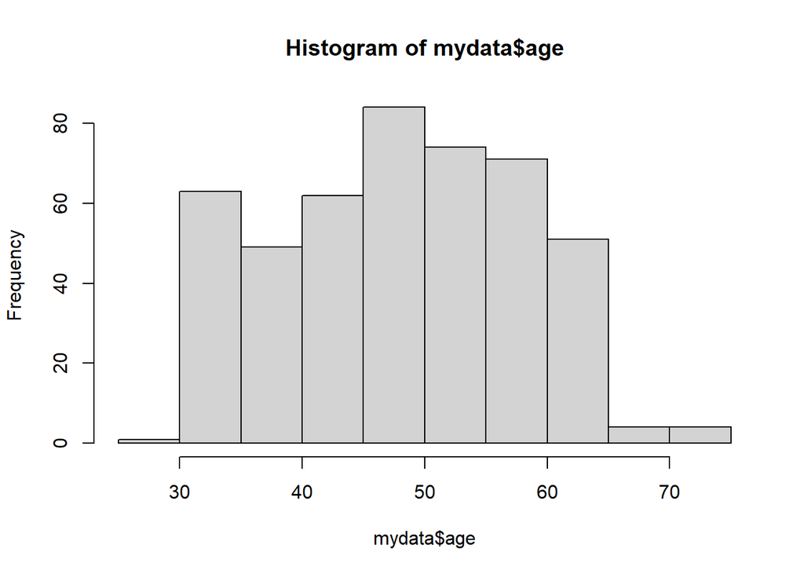

```r
hist(mydata$age)
```

```r
summary(mydata$beauty)
```

```
##       Min.    1st Qu.     Median       Mean    3rd Qu.       Max.
## -1.4504940 -0.6562689 -0.0680143  0.0000001  0.5456024  1.9700230
```

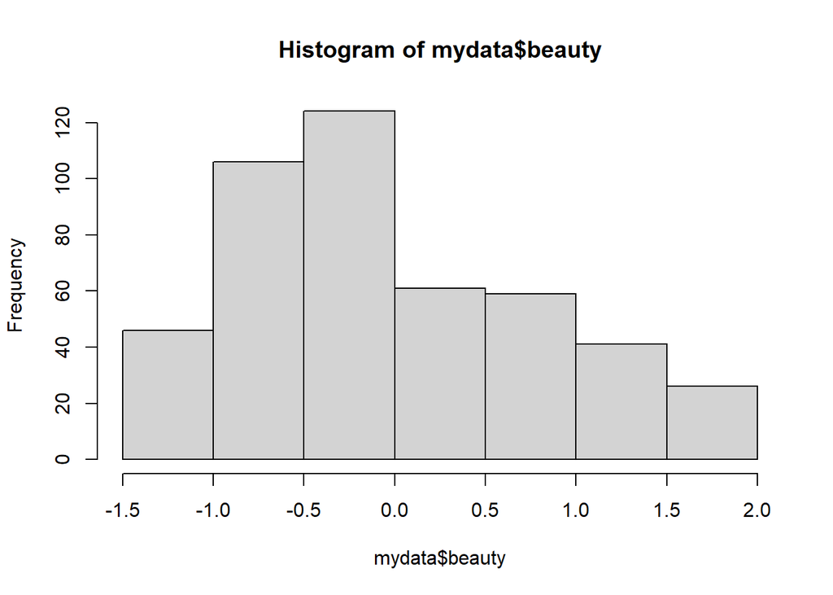

```r
hist(mydata$beauty)
```

```r
summary(mydata$eval)
```

```
##    Min. 1st Qu.  Median    Mean 3rd Qu.    Max.
##   2.100   3.600   4.000   3.998   4.400   5.000
```

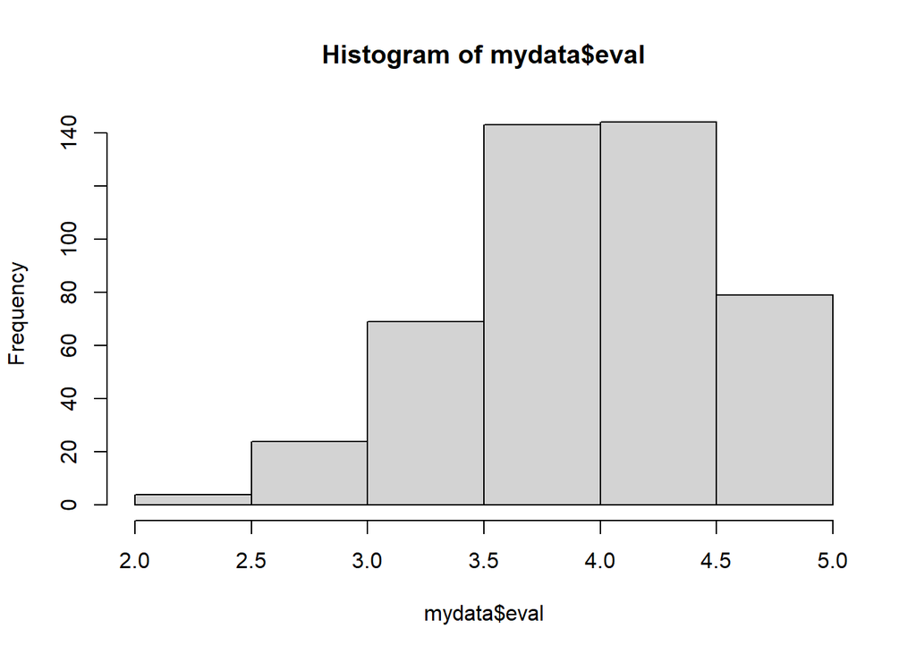

```r
hist(mydata$eval)
```

**Descriptive Statistics-qualitative**

Since these are categorical, we’re looking mostly for frequencies.

```r
g<-table(mydata$gender)
g
```

```
##
## female   male
##    195    268
```

```r
gpercent<-prop.table(g)*100
gpercent
```

```
##
##   female     male
## 42.11663 57.88337
```

```r
div<-table(mydata$division)
div
```

```
##
## lower upper
##   157   306
```

```r
divpercent<-prop.table(div)*100
divpercent
```

```
##
##    lower    upper
## 33.90929 66.09071
```

Now trying this with the package Hmisc. First, I have to call that package with the library function, then I can use the “describe” feature.

```r
library(Hmisc)
describe(mydata$minority)
```

```
## mydata$minority
##        n  missing distinct
##      463        0        2
##
## Value         no   yes
## Frequency    399    64
## Proportion 0.862 0.138
```

```r
describe(mydata$tenure)
```

```
## mydata$tenure
##        n  missing distinct
##      463        0        2
##
## Value        no  yes
## Frequency   102  361
## Proportion 0.22 0.78
```

That was definitely simpler. :)

**Plots!**

When I do this, I chose two variables to plot, one on the x-axis, one on the y-axis. Then I label them so with their actualy variabel titles not their program titles.

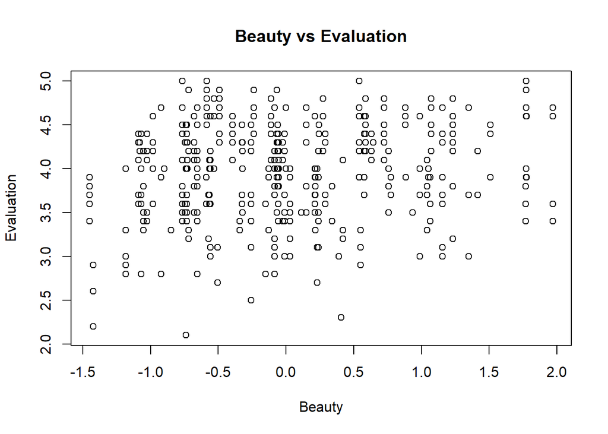

```r
plot(mydata$beauty,mydata$eval, xlab="Beauty", ylab = "Evaluation", main = "Beauty vs Evaluation")
```

Here’s some boxplots!

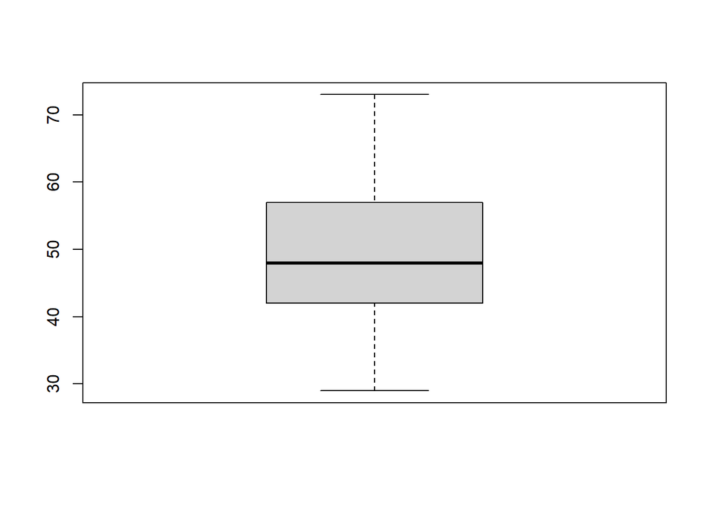

```r
boxplot(mydata$age)
```

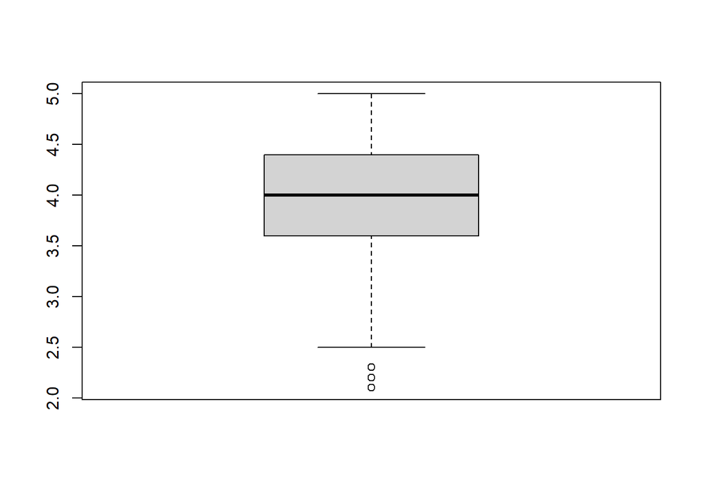

```r
boxplot(mydata$eval)
```

**Transforming with log**

We’ll start with the variable “students”

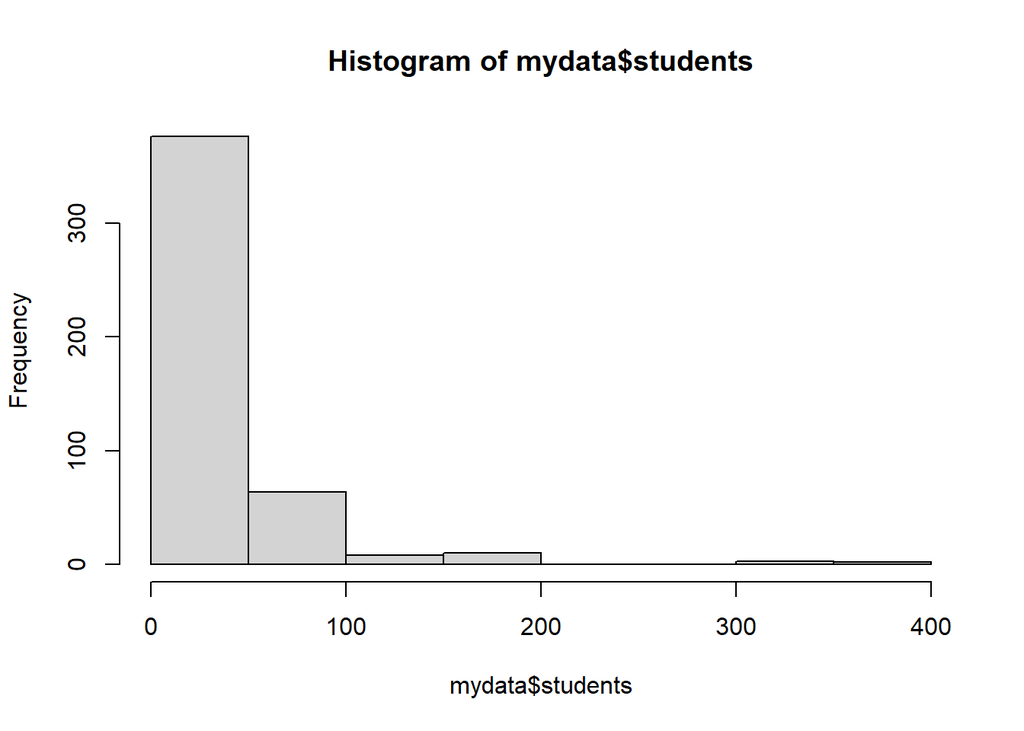

```r
hist(mydata$students)
```

This histogram is a bit skewed, so we can transform the data into its logs to analyze:

```r
transform<-log10(mydata$students)
transform
```

[output not shown]

[output cut: 52 more lines]

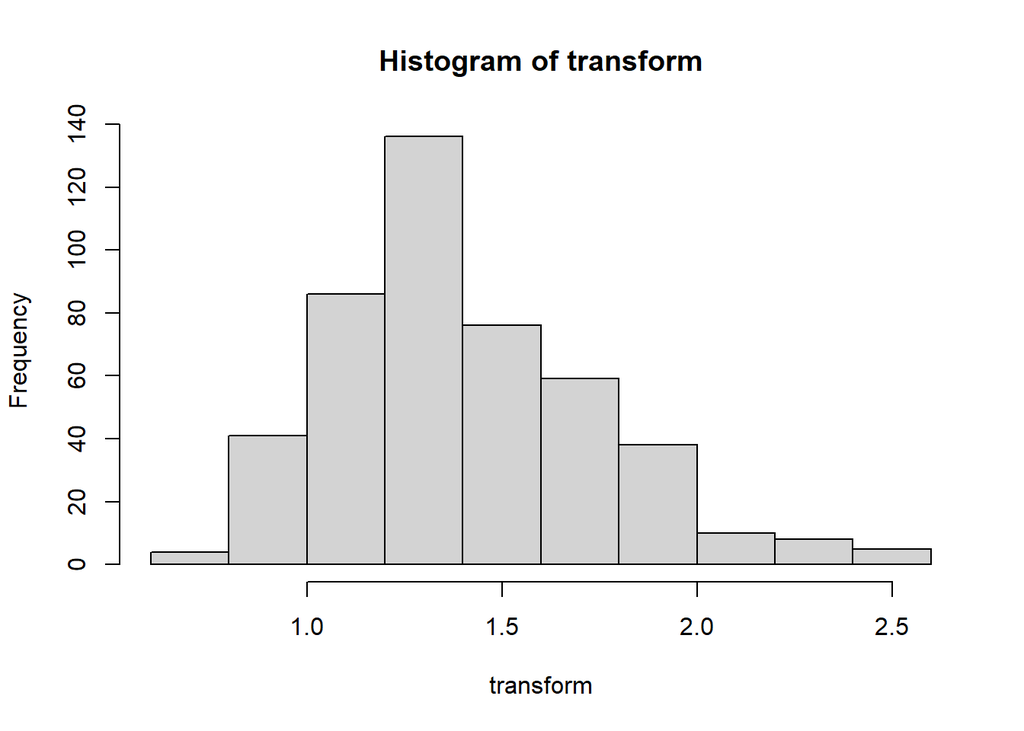

```r
hist(transform)
```

Now the data can be analyzed. Yay R!